# Pset 1 - Water usage

425/625

Spring 2024

## Introduction

Water scarcity is a major issue in many parts of the world. According to the [United Nations](https://www.un.org/en/climatechange/science/climate-issues/water), “About two billion people worldwide don’t have access to safe drinking water today ([SDG Report 2022](https://unstats.un.org/sdgs/report/2022/Goal-06/?_gl=1*aquqlc*_ga*MTAzMzA2ODI0Mi4xNzA0NjYzNjY3*_ga_TK9BQL5X7Z*MTcwNDY2NzIyMS4yLjEuMTcwNDY2NzI1My4wLjAuMA..)), and roughly half of the world’s population is experiencing severe water scarcity for at least part of the year ([IPCC](https://www.ipcc.ch/report/ar6/wg2/downloads/outreach/IPCC_AR6_WGII_FactSheet_FoodAndWater.pdf)). These numbers are expected to increase, exacerbated by climate change and population growth ([WMO](https://public.wmo.int/en/media/press-release/protect-our-people-and-future-generations-water-and-climate-leaders-call-urgent)).”

In this problem set, we will investigate water usage estimates by crop in the United States. The `.csv` for this data set comes from [here](https://databank.illinois.edu/datasets/IDB-4607538) (by checking Select All and clicking Get Custom Zip) and the associated academic journal article is [here](https://agupubs.onlinelibrary.wiley.com/doi/10.1029/2022WR032804). See [this thread](https://twitter.com/MeganKonar/status/1618943789279875074?s=20&t=nrjRJQ2tuEO0GyTwCK-XVA) on X for a summary.

Read the academic article to familiarize yourself with the basics of the water usage data. You don’t need to know how these water usage levels were estimated, so you can skip over those parts. We are going to focus on visualizing the water levels using the estimates that they generated.

## Data preparation

The `.zip` file `rawdata/DOI-10-13012-b2idb-4607538_v1.zip` contains one `.csv` file per source (SWW, GWW, GWD) per year from 2008 to 2020. There are also a couple of `.txt` files in the folder. We can use `unzip` with `list = TRUE` to see what’s in the `.zip` file.

```r
unzip(zipfile = 'rawdata/DOI-10-13012-b2idb-4607538_v1.zip',
      list = TRUE) ## this lists the filename, but does not unzip the file
```

```
##                                              Name  Length                Date
## 1        DOI-10-13012-b2idb-4607538_v1/readme.txt    1053 2023-10-29 14:08:00
## 2      DOI-10-13012-b2idb-4607538_v1/gwa_2008.csv 2274812 2023-10-29 14:08:00
## 3      DOI-10-13012-b2idb-4607538_v1/gwa_2009.csv 2274812 2023-10-29 14:08:00
## 4      DOI-10-13012-b2idb-4607538_v1/gwa_2010.csv 2200859 2023-10-29 14:08:00
## 5      DOI-10-13012-b2idb-4607538_v1/gwa_2011.csv 2274812 2023-10-29 14:08:00
## 6      DOI-10-13012-b2idb-4607538_v1/gwa_2012.csv 2274812 2023-10-29 14:08:00
## 7      DOI-10-13012-b2idb-4607538_v1/gwa_2013.csv 2274812 2023-10-29 14:08:00
## 8      DOI-10-13012-b2idb-4607538_v1/gwa_2014.csv 2274812 2023-10-29 14:08:00
## 9      DOI-10-13012-b2idb-4607538_v1/gwa_2015.csv 2200859 2023-10-29 14:08:00
## 10     DOI-10-13012-b2idb-4607538_v1/gwa_2016.csv 2275517 2023-10-29 14:08:00
## 11     DOI-10-13012-b2idb-4607538_v1/gwa_2017.csv 2275517 2023-10-29 14:08:00
## 12     DOI-10-13012-b2idb-4607538_v1/gwa_2018.csv 2275517 2023-10-29 14:08:00
## 13     DOI-10-13012-b2idb-4607538_v1/gwa_2019.csv 2275517 2023-10-29 14:08:00
## 14     DOI-10-13012-b2idb-4607538_v1/gwa_2020.csv 2275517 2023-10-29 14:08:00
```

[output cut: 27 more lines]

Before summarizing/visualizing this data, we’ll want to join these data sets. We could certainly unzip the file manually. We can also do this in R using `unzip`.

```r
unzip(zipfile = 'rawdata/DOI-10-13012-b2idb-4607538_v1.zip',
      junkpaths = TRUE,
      exdir = 'rawdata') ## gets rid of paths, keeps only filenames
```

#### 1. Join data

First, let’s create a data set with all years/crops together in one data frame. Below is some code to help you get started. Add comments to each place there is `##` to explain what the chunk of code is doing. Then add code to the `Tranforming data` Section to transform the data into a data frame with 5 columns: `GEOID`, `crop`, `source`, `year`, and `value` (indicating km^3 of water).

Note that `eval = F` at the start of the chunk will prevent this chunk from evaluating when you knit the document. You can temporarily remove it if you’d like, but you’ll want to add it back before knitting the document so that knitting takes less time.

```r
sources = c('gwd', 'sw', 'gwa')
years = 2008:2020
d = NULL

for(s in sources){
  cat(s, '') ## show progress

  for(year in years){
    cat(year, '') ## show progress

    ## Read in data by combining 'rawdata/', source, '_', year, '.csv' into a filename
    filename = paste0('rawdata/', s, '_', year, '.csv')
    df = read.csv(filename)
    head(df)


    ## Tranform data #######################################
    ## Use `pivot_longer`, `separate`, and/or other functions to transform this
    ## data frame into a data frame with 5 columns:
    ## GEOID, crop, source, year, and value (indicating km^3 of water)
    df = df %>%
      pivot_longer(cols = -GEOID, names_to = "crop", values_to = "value") %>%
      separate(col = crop, into = c("crop", "source", "year"), sep = "\\.")

    ## end of transforming data ############################

    ## Add this dataframe to `d`, which is a collection of all previous data frames
    d = rbind(d, df)
  }

  cat('\n') ## start a new line before showing progress for the next source
}
head(d)
tail(d)
```

## Data exploration and summaries

Let’s load the data we’ll use for the rest of the assignment. This is the data set created in #1, so if you were unable to finish #1, you can still do the rest of the assignment.

```r
d = readRDS('data/water.usage.rds')
head(d)
```

```
## # A tibble: 6 × 5
##   GEOID crop        src   year  value
##   <int> <chr>       <chr> <chr> <dbl>
## 1  1001 barley      gwd   2008      0
## 2  1001 corn        gwd   2008      0
## 3  1001 cotton      gwd   2008      0
## 4  1001 millet      gwd   2008      0
## 5  1001 oats        gwd   2008      0
## 6  1001 other_sctg2 gwd   2008      0
```

#### 2. Summaries of data

Find the mean, the change from 2008 to 2020, and the percent change from 2008 to 2020, for each crop and each source (SWW, GWW, GWD).

```r
(dd1 <- d %>%
  group_by(crop, src, year) %>%
  summarise(value = sum(value)) %>%
  group_by(crop, src) %>%
  mutate(mean = mean(value)) %>%
  pivot_wider(names_from = year, values_from = value) %>%
  mutate(change = `2020` - `2008`) %>%
  mutate(percent_change = (change/`2008`)*100) %>%
  select(crop, src, mean, change, percent_change))
```

```
## # A tibble: 60 × 5
## # Groups:   crop, src [60]
##    crop   src     mean  change percent_change
##    <chr>  <chr>  <dbl>   <dbl>          <dbl>
##  1 barley gwa   1.19    0.0631           5.21
##  2 barley gwd   0.711  -0.118          -17.4
##  3 barley sw    2.20   -0.508          -21.4
##  4 corn   gwa   5.65    0.617           11.5
##  5 corn   gwd   3.52   -0.167           -4.61
##  6 corn   sw    5.50   -2.19           -30.7
##  7 cotton gwa   2.00   -0.0846          -5.19
##  8 cotton gwd   1.42    0.154           15.1
##  9 cotton sw    1.66   -1.05           -54.7
## 10 millet gwa   0.0740  0.0241          27.2
## # ℹ 50 more rows
```

## 3. Convert Table 2 to a visualization

Create a visual representation of the information in Table 2. Create a visualization (or visualizations) that contains mean, change, and percent change in water usage from each crop and source.

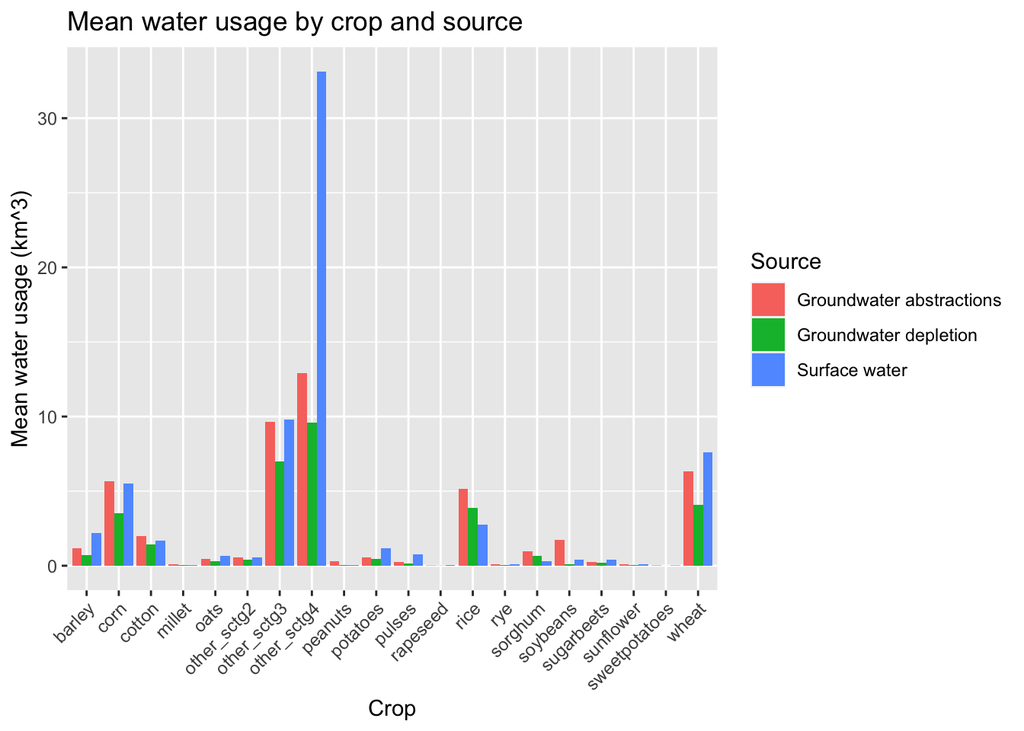

```r
## Bar chart of mean water usage by crop and source

(g1 <-  ggplot(dd1, aes(x = crop, y = mean, fill = src)) +
          geom_bar(stat = "identity", position = "dodge") +
          labs(x = "Crop", y = "Mean water usage (km^3)", title = "Mean water usage by crop and source", fill = "Source") +
          geom_bar(stat = "identity", position = position_dodge(width = 0.9)) +
          theme(axis.text.x = element_text(angle = 45, hjust = 1)) +
          scale_fill_discrete(labels = c("Groundwater abstractions", "Groundwater depletion", "Surface water")))
```

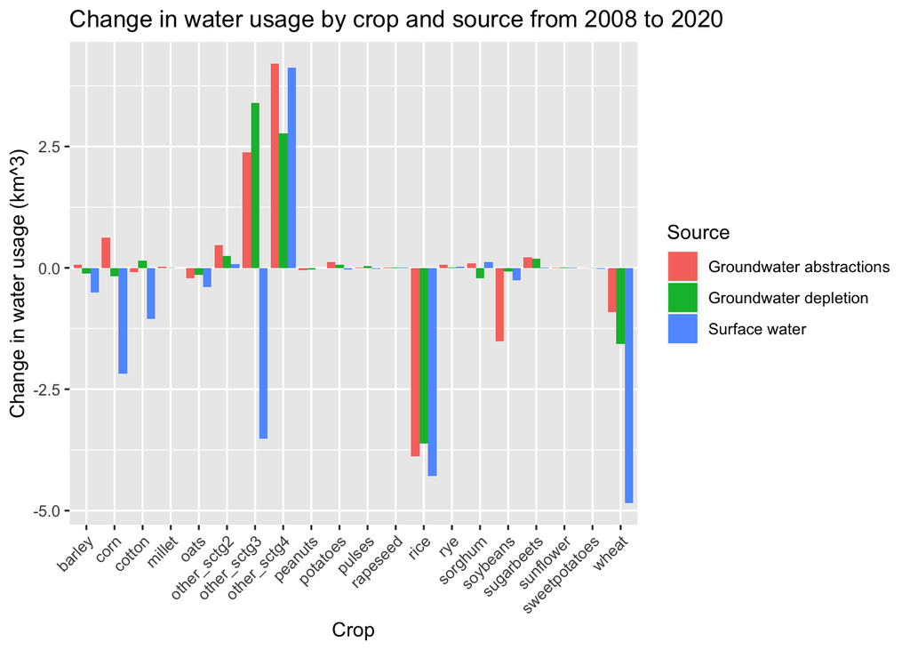

```r
## Bar chart of change in water usage by crop and source

(g2 <-  ggplot(dd1, aes(x = crop, y = change, fill = src)) +
          geom_bar(stat = "identity", position = "dodge") +
          labs(x = "Crop", y = "Change in water usage (km^3)", title = "Change in water usage by crop and source from 2008 to 2020", fill = "Source") +
          geom_bar(stat = "identity", position = position_dodge(width = 0.9)) +
          theme(axis.text.x = element_text(angle = 45, hjust = 1)) +
          scale_fill_discrete(labels = c("Groundwater abstractions", "Groundwater depletion", "Surface water")))
```

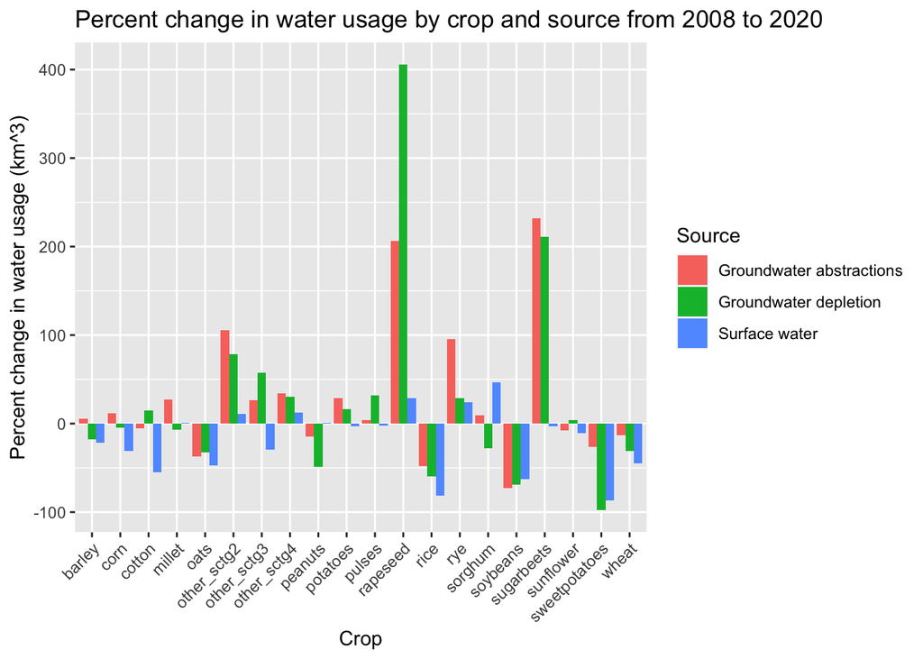

```r
## Bar chart of percent change in water usage by crop and source

(g3 <-  ggplot(dd1, aes(x = crop, y = percent_change, fill = src)) +
          geom_bar(stat = "identity", position = "dodge") +
          labs(x = "Crop", y = "Percent change in water usage (km^3)", title = "Percent change in water usage by crop and source from 2008 to 2020", fill = "Source") +
          geom_bar(stat = "identity", position = position_dodge(width = 0.9)) +
          theme(axis.text.x = element_text(angle = 45, hjust = 1)) +
          scale_fill_discrete(labels = c("Groundwater abstractions", "Groundwater depletion", "Surface water")))
```

# Figure 4

Figure 4 shows the average water usage by crop and source.

- A. average irrigation water usage by source, colored by crop,
- B. average irrigation water usage by crop, colored by source

Two other options for visualizing a numeric variable broken down by two different categorical variable would be a tile plot/grid plot (e.g. https://github.com/bmacGTPM/pubtheme?tab=readme-ov-file#grid-plot) and a mosiac plot (https://haleyjeppson.github.io/ggmosaic/).

## 4. Create a tile plot/grid plot of the data in Figure 4.

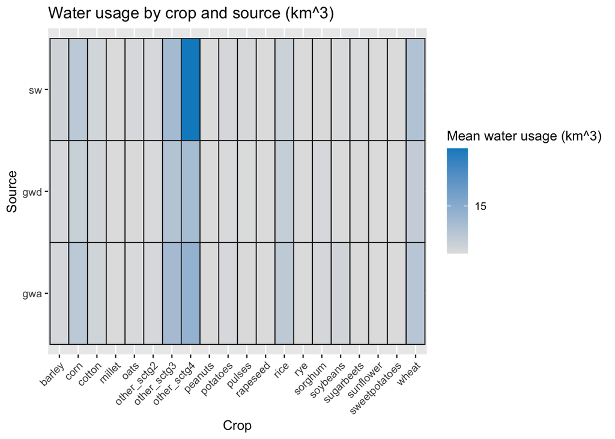

```r
## From pubtheme repo

title = "Water usage by crop and source (km^3)"
(g = ggplot(dd1,
           aes(x    = crop,
               y    = src,
               fill = mean)) + ## hacky way to add a legend for NA values. See below
  geom_tile(linewidth   = 0.4,
            show.legend = T,
            color       = pubdarkgray) +
  scale_fill_gradient(low      = pubgradgray,
                      high     = pubblue,
                      na.value = pubmediumgray, ## same color as below
                      oob      = squish,
                      breaks   = c(0, 15, 40)) +

  ## hacky way to add a legend for NA values

  labs(title    = title,
       x    = 'Crop',
       y    = 'Source', ## Optional
       fill = 'Mean water usage (km^3)') +
  theme(axis.text.x = element_text(angle = 45, hjust = 1)))
```

```r
# Omitting this because it does something weird to the format
# g %>%
   # pub(type  = 'grid')
```

## 5. Create a mosiac plot of the data in Figure 4.

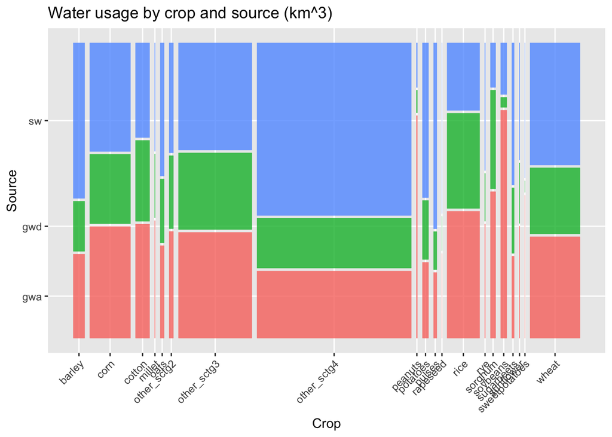

```r
(g = ggplot(dd1) +
  geom_mosaic(aes(weight = mean, x = crop, fill = src), show.legend = F) +
  labs(title = "Water usage by crop and source (km^3)", x = "Crop", y = "Source", fill = "Source") +
  theme(axis.text.x = element_text(angle = 45, hjust = 1)))
```

## 6. What are the benefits (other than it fits on one plot) and drawbacks of these two plots?

In the tile plot, there is a value (other_sctg4, sw) that has a much higher value than the rest of the values. This causes some granularity to be lost when visualizing the rest of the values since they are close together and lumped into similar color bins. It is, however, easier to quickly see the difference between values.

The mosiac plot is able to show the granularity of the values better since it also represents the value with the bar widths. However, this does cause an issue when some bars are very narrow and the labels are too close together to read.

## 7. Figure 6

Figure 6 uses a different color scale for each plot. Discuss the benefits and drawbacks of this choice. What was the main purposes of this figure? Given the main purpose, would you recommend using the same color scale, or different color scales, for each plot?

## 8. Figure 8

Figure 8 also uses a different color scale for each plot. Discuss the benefits and drawbacks of this choice. What was the main purposes of this figure? Given the main purpose, would you recommend using the same color scale, or different color scales, for each plot?

Using a different color scale for this figure may not be as advantageous as the previous example because the values are meant to be compared across time, as seen on the y-axis. However, it still serves the same purpose of comparing regional difference in value within each map.

## 9. Breakdown of GWW

The paper notes in Section 3.1 that $GWW = GWW_{sustainable} + GWW_{unsustainable}$, and that $GWD = GWW_{unsustainable}$. Create a visualization showing the percent of GWW that is GWD for each crop. Use the mean values for water usage.

## 10. Custom visualization

What is another question you have about this data? Create a visualization that attempt to answer your question.

I am curious about the distribution of water usage by crop and source and I want to visually compare the values going from each crop and going from each source. I’ve created a chord diagram to visualize this.

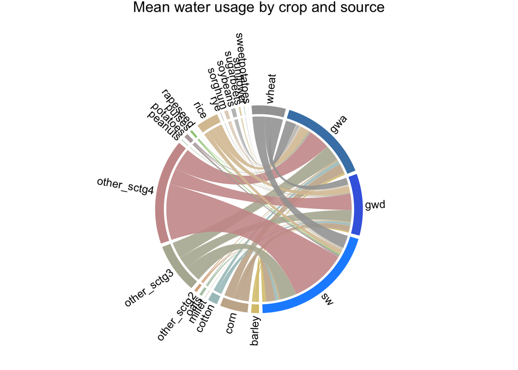

```r
## Chord diagram of water usage by crop and source
dd2 <- dd1 %>% select(crop, src, mean)
colnames(dd2) <- c("x", "y", "z")

colors <- c("#D9C57C", "#C7B299", "#A8C4C4", "#C4BAA1", "#B3C7B3", "#D9B08C", "#B4B4A0", "#CC9999", "#C4D0C0", "#B6A9A9", "#9ECA83", "#BCB5A1", "#DAC3A1", "#B0B0B0", "#E2D3C3", "#C0C0C0", "#E2D5B2", "#B0C0C0", "#D1CBB9", "#A3A3A3", "#4682B4", "#4169E1", "#1E90FF")

circos.clear()
circos.par(
  canvas.xlim = c(-0.25, 0.25),
  canvas.ylim = c(-1.1, 1.5),
  start.degree = 270,
  gap.degree = 2
)
chordDiagram(dd2, transparency = .1, grid.col = colors, annotationTrack = "grid",
    preAllocateTracks = list(track.height = max(strwidth(unlist(dimnames(dd2))))))
circos.track(track.index = 1, panel.fun = function(x, y) {
    circos.text(CELL_META$xcenter, CELL_META$ylim[1], CELL_META$sector.index,
        facing = "clockwise", niceFacing = TRUE, adj = c(0, 0.5), cex = 0.9)
}, bg.border = NA)
mtext("Mean water usage by crop and source", side = 3, cex = 1.2)
```